# Projekat iz obrade prirodnih jezika.

#### Marija Jošić 2021/3055

#### Aleksa Veličković 2020/3358

#### Nikola Stojanović 2021/3433

#### Vojin Dedović 2021/3060

# Uvod

Zadatak ovog projekta jeste aspekta analiza sentimenta tekstova na srpskom jeziku. Potrebno je formirati sistem koji predviđa iz teksta na srpskom jeziku pripadnost aspektnoj kategoriji kao i sentiment prema toj kategoriji ukoliko postoji pripadnost. Sistemi uključuju modele mašinskog učenja pri čemu modeli treba biti trenirani na podacima koje projektanti anotiraju i/ili prikupljaju. Zadatak se radi korišćenjem različitih pristupa i različitih konfiguracija unutar tih pristupa o čemu se može pročitati u nastavku ovog izveštaja

# O skupu podataka

Skup podataka se sastoji iz komentara na filmske recenzije. Obrađeni skup podataka se nalazi na repozitorijumu https://github.com/vukbatanovic/SentiComments.SR.git, konkretno obrađene su datoteke: SentiComments.SR.corr.txt i SentiComments.SR.verif.movies.txt. Podaci su prikupljeni sa veb stranica kakavfilm.com, gledajme.rs i happynovisad.com.

# Aspektne kategorije

Na timskom ”brainstorming” sastanku su na osnovu 500 nasumično izabranih komentara zajedničkim razmatranjem odabrane sledeće aspektne kategorije:

- Radnja
- Režija
- Gluma
- Muzika
- Opšti utisak film
- Opšti utisak komentar
- Specijalni efekti.

Svakoj aspektnoj kategoriji koja je prepoznata u tekstu je moguće dodeliti jedan od tri sentimenta (pozitivan, negativan ili neutralan).

# Uputstvo za anotaciju

U nastavku sledi kratko uputstvo za anotiranje po aspektnim kategorijama:

- Radnja - Pojavljuje se kada se u tekstu ekspicitno pominje "radnja je...", ili "scenario je...", "skripta je...", "priča je...". Takođe smo definisali tako da se pojavljuje ukoliko se nešto o scenaristi govori u tekstu.
- Režija - Eksplicitno se pojavljluje ili se pominje rad režiserke/režisera
- Gluma - Ova aspektna kategorija se pojavljuje kada se eksplicitno govori o njoj u tekstu ili ukoliko je pomenuto ime glumice/glumca (npr. "Leonardo je bio izuzetan")
- Muzika - Eksplicitno se pominje (reči kao muzika, pesma, soundtrack, skor), kao i ukoliko se komentariše rad kompozitora ili izvođača u komentaru.
- Opšti utisak o filmu - Ova kategorija se pojavljuje svuda gde se eksplicitno pominje utisak o filmu. Ova kategorija nam je pre svega korisna kada se ceo komentar o filmu svede na primere kao "Super film!" ili "Ne sviđa mi se.". Ova kategorija neće svuda biti zastupljena jer postoje komentari koji su odgovori na druge komentare i oni često ne pominju film ni u kakvom kontekstu.
- Opšti utisak komentar - Ovo je uzeto zato što se dosta komentara pojavljivalo gde neko pomene da je film precenjen/podcenjen ili da je/nije zaslužio ocenu sa tog sajta. Takođe se često dešava da u prepirci između komentara postoji slaganje ili neslaganje o utiscima o filma.
- Specijalni efekti - Eksplicitno se pominje ili se pominju reči: kamera, fotografija, produkcija

## Label-studio

Da bi se lakše izvšilo anotiranje podataka korišćen je program Label-studio. Program je pokrenut lokalno i definisanjem filtera je podeljen skup tako da svaki član tima ima podjednak deo za anotaciju.

Pre nego što se krenulo sa anotacijom, svaki član tima je imao istu konfiguraciju za anotiranje u projektu:

```
<View>
  <Text name="text" value="$text"/>
  <View style="box-shadow: 2px 2px 5px #999;
               padding: 20px; margin-top: 2em;                border-radius: 5px;">
    <Header value="Radnja"/>
    <Choices name="Radnja" toName="text" choice="single" showInLine="true">
      <Choice value="Positive"/>
      <Choice value="Negative"/>
      <Choice value="Neutral"/>
      <Choice value="None" selected="true"/>
    </Choices>

    <Header value="Rezija"/>
    <Choices name="Rezija" toName="text" choice="single" showInLine="true">
      <Choice value="Positive"/>
      <Choice value="Negative"/>
      <Choice value="Neutral"/>
      <Choice value="None" selected="true"/>
    </Choices>

    <Header value="Gluma"/>
    <Choices name="Gluma" toName="text" choice="single" showInLine="true">
      <Choice value="Positive"/>
      <Choice value="Negative"/>
      <Choice value="Neutral"/>
      <Choice value="None" selected="true"/>
    </Choices>

    <Header value="Muzika"/>
    <Choices name="Muzika" toName="text" choice="single" showInLine="true">
      <Choice value="Positive"/>
      <Choice value="Negative"/>
      <Choice value="Neutral"/>
      <Choice value="None" selected="true"/>
    </Choices>

    <Header value="Opsti utisak film"/>
    <Choices name="Opsti utisak film" toName="text" choice="single" showInLine="true">
      <Choice value="Positive"/>
      <Choice value="Negative"/>
      <Choice value="Neutral"/>
      <Choice value="None" selected="true"/>
    </Choices>

    <Header value="Opsti utisak komentar"/>
    <Choices name="Opsti utisak komentar" toName="text" choice="single" showInLine="true">
      <Choice value="Positive"/>
      <Choice value="Negative"/>
      <Choice value="Neutral"/>
      <Choice value="None" selected="true"/>
    </Choices>

    <Header value="Specijalni efekti"/>
    <Choices name="Specijalni efekti" toName="text" choice="single" showInLine="true">
      <Choice value="Positive"/>
      <Choice value="Negative"/>
      <Choice value="Neutral"/>
      <Choice value="None" selected="true"/>
    </Choices>
  </View>
</View>
```

Svi članovi tima su po završetku anotiranja kao rezultat izvezli po jedan csv fajl i svi ti fajlovi su spojeni nakon toga u jedan. Kolone koje se pojavljuju su identifikator komentara, tekst komentara i svaka aspektna kategorija se pojavljuje kao zasebna kolona.

# Analiza podataka nakon anotacije

Nakon završene faze anotacije komentara pristupilo se analizi podataka.

## Raspodela podataka po aspektnim kategorijama (prva iteracija)

Tabelarni prikaz prvih 5 redova iz fajla koji sadrži anotacije:

|  | Unnamed: 0 | text | Radnja | Rezija | Gluma | Muzika | Opsti utisak film | Opsti utisak komentar | Specijalni efekti |
| --- | --- | --- | --- | --- | --- | --- | --- | --- | --- |
| 0 | 0 | Film je užasan, realna ocena 2/10. Ako vam se ... | None | None | None | None | Negative | None | None |
| 1 | 2 | Interesantan! | None | None | None | None | Positive | None | None |
| 2 | 3 | Odličan film, odlična recenzija. | None | None | None | None | Positive | Positive | None |
| 3 | 4 | Treba dodati i fantastičnu muziku koja prati c... | None | None | None | Positive | None | None | None |
| 4 | 6 | Dobar film, vrlo dobar. Recenzija je sve objas... | None | None | None | None | Positive | None | None |

Ukupan broj komentara kojima je dodeljena bar jedna aspektna kategorija:

```
2723
```

U nastavku sledi prikaz raspodele podataka po aspektnim kategorijama:

```
          Radnja
Positive     129
Negative      81
Neutral       42
None        2471
```

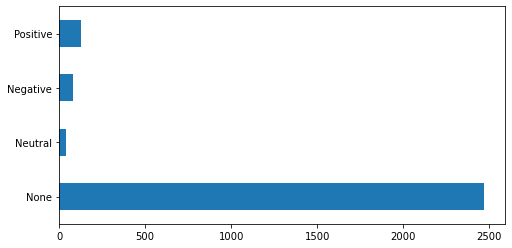

```
          Rezija
Positive     130
Negative      34
Neutral       27
None        2532
```

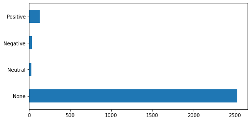

```
          Gluma
Positive    329
Negative     47
Neutral      39
None       2308
```

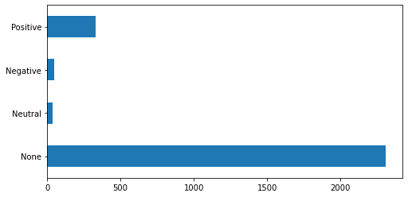

```
          Muzika
Positive      58
Negative       2
Neutral        4
None        2659
```

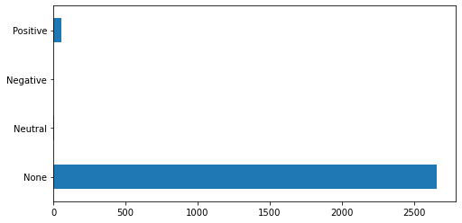

```
          Opsti utisak film
Positive               1459
Negative                545
Neutral                 266
None                    453
```

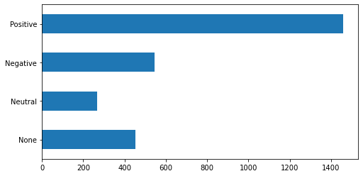

```
          Opsti utisak komentar
Positive                    355
Negative                    123
Neutral                      52
None                       2193
```

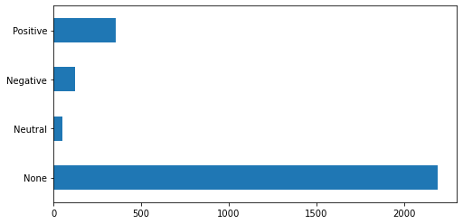

```
          Specijalni efekti
Positive                 84
Negative                  8
Neutral                   8
None                   2623
```

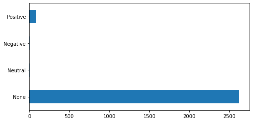

Na osnovu do sada viđenog možemo zaključiti da je jedina kategorija koja ima iole ravnemernu raspodelu kategorija sa nazivom **Opšti utisak film**. Kategorije koje još imaju raspodelu koja bi eventualno mogla da se uzme u obzir za kasnije obučavanje modela su još **Opšti utisak komentar** i **Gluma**. Ostale kategorije nemaju dovoljno primera da bi se uzele u razmatranje.

Na osnovu svega navedenog odlučeno je da je neophodno da se anotiraju dodatni komentari.

## Raspodela podataka po aspektnim kategorijama (druga iteracija)

U drugoj iteraciji su dodati duži komentari za anotaciju.

Ukupan broj komentara kojima je dodeljena bar jedna aspektna kategorija nakon druge iteracije:

[output not shown]

Sledi uporedi prikaz prve i druge iteracije po aspektnim kategorijama:

```
Radnja
          first iteration  second iteration
Positive              129               203
Negative               81               165
Neutral                42                72
None                 2471              3276
```

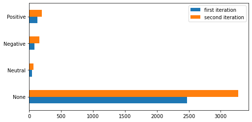

```
Rezija
          first iteration  second iteration
Positive              130               208
Negative               34                66
Neutral                27                50
None                 2532              3392
```

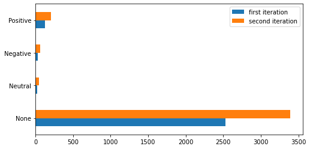

```
Gluma
          first iteration  second iteration
Positive              329               457
Negative               47                72
Neutral                39                60
None                 2308              3127
```

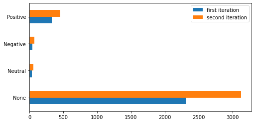

```
Muzika
          first iteration  second iteration
Positive               58               103
Negative                2                 5
Neutral                 4                 7
None                 2659              3601
```

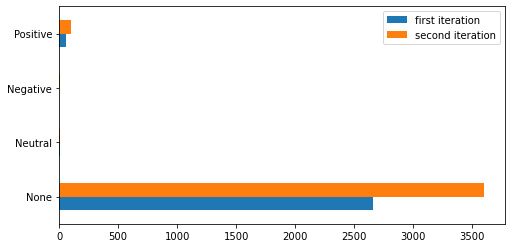

[output not shown]

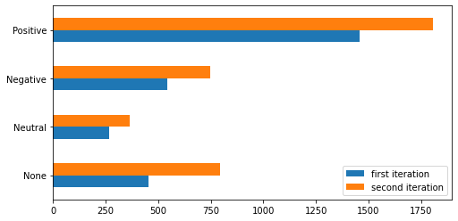

```
Opsti utisak komentar
          first iteration  second iteration
Positive              355               458
Negative              123               226
Neutral                52                60
None                 2193              2972
```

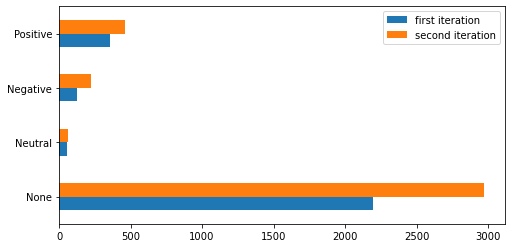

```
Specijalni efekti
          first iteration  second iteration
Positive               84               141
Negative                8                14
Neutral                 8                10
None                 2623              3551
```

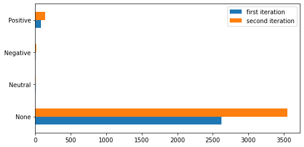

Nažalost ni nakon druge iteracije nije značajno poboljšana raspodela po aspektnim kategorijama. Na kraju, aspektne kategorije koje su izabrane za obučavanje modela su:

- Opšti utisak film
- Opšti utisak komentar
- Gluma

# Obučavanje i evaluacija statističkih modela

Zadatak je kreirati, obučiti i evaluirati statističke modele tako da uspešno predvide aspektnu kategoriju i sentiment iz komentara. U tekstu postavke projekta predlažu se tri statistička modela. Naivni Bayes, logistička regresija i metoda potpornih vektora. Za svaki ovaj model preporuka je metodom krosvalidacije utvrditi optimalne hiperparametre za koje ovi modeli maksimizuju odabranu metriku. Preporučuje se desetostruka krosvalidacija.

Takođe je potrebno utvrditi kakav uticaj razne metode preprocesiranja teksta (i obeležja) utiču na performanse statističkih modela.

Obzirom da je broj mogućih kombinacija statističkih modela i metoda preprocesiranja jako veliki, autori ovog projekta su zarad uštede vremena i koncizne prezentacije sistematski razmotrili samo pojedine kombinacije za koje autori smatraju da se izdvajaju kada se uzme u obzir teorijsko znanje.

U tekstu zadatka projekta se navodi da je potrebno obuciti modele na dva nacina.

- Prvi način predstavlja obučavanje u dve faze gde se za svaku aspektnu kategoriju formiraju dva modela. Jedan model predviđa pripadnost aspektnoj kategoriji, dok drugi model predviđa sentiment te aspektne kategorije ukoliko komentar pripada njoj. U nastavku ćemo prvi način oslovljavati kao *odvojena analiza*.
- Drugi način je obučavanje u jednom koraku, gde se za svaku aspektnu kategoriju formira jedan model koji predviđa i pripadnost i sentiment ka toj aspektnoj kategoriji (tako što uvodi nepripadnost kao dodatnu klasu). U nastavku ćemo drugi način oslovljavati kao *zajednička analiza*.

Autori projekta vide zadatak iz zajedničke analize (višeklasna klasifikacija) kao *podskup odvojene analize gde se u drugoj fazi takođe vrši zadatak višeklasne klasifikacije*. Zato je većina kombinacija iscrpljena na odvojenoj analizi. A na kraju je optimalna konfiguracija dobijena u drugoj fazi odvojene analize korišćena i prilikom zajedničke analize.

Iz predloženih statističkih modela izdvajaju se dva diskriminativna i jedan generativni. Ideja autora je da se vrši poređenje između ove dve paradigme obučavanja. U ovom poređenju većina rezultata diskriminativnih modela je generisana koristeći metodu potpornih vektora. Razlog za to je veća reprezentativna moć metode potpornih vektora u odnosu na logističku regresiju jer je moguće koristi nelinarni kernel odnosno formirati nelinearne granice odlučivanja. Čak iako ovaj kompleksniji klasifikator da lošije rezultate usled preobučavanja, korišćenjem linearnog kernela osobine ovog klasifikatora svodimo na osobine logističke regresije (linearna granica odlučivanja). Zbog ovoga autori smatraju da je redudantno ponavljati iste konfiguracije za ova dva diskriminativna modela.

Za svaku aspektnu kategoriju (ili sentiment) model je treniran na posebno podeljenom skupu podataka tako da isti procenat svake klase završi i u trening i u test skupu. Odnosno izvršena je stratifikacija.

U nastavku su priloženi rezultati kros-validacije, obučavanja i testiranja različitih konfiguracija nad različitim statističkim modelima.

Korišćen je programski jezik `Python`. I biblioteke `numpy, pandas, scikit-learn, nltk, gensim, pytorch, matplotlib`.

**Napomena** Inicijalna konfiguracija podrazumeva nekorišćenje ni jedne metode preprocesiranja iz teksta zadatka uz korišćenje vreće unigrama kao obeležja. Autori su u svakoj kofiguraciji primenili preprocesiranje u vidu pretvaranja ćirilice u latinicu kao i uklanjanje znakova interpunkcije

# Odvojena analiza

## Naivni Bayes

Naivni Bayes je generativni model koji formira raspodelu podataka na osnovu estimacije parametara te raspodele. Ključna razlika Naivnog Bayesa u odnosu na druge generativne modele jeste pretpostavka statističke nezavisnosti izmedju različith obeležja.

Za svaku konfiguraciju pokrenuta je krosvalidacija kako bi se našao optimalan parametar Laplasovog izglađivanja. Pri čemu je korišćeno deset vrednosti ovog parametra u opsegu od 0 do 1.

### Kros-validacija i obučavanje

U nastavku su tabelarno prikazani rezultati za različite konfiguracije

#### Predviđanje aspektnih kategorija

##### Optimalni hiperparametri Laplasovog izglađivanja

|  | initial | lowercase | lowercase, tfidf | lowercase, binary BOW | lowercase, 2-gram | lowercase, stop-words | lowercase, stop-words, stem |
| --- | --- | --- | --- | --- | --- | --- | --- |
| Opsti utisak film | 0.2223 | 0.1112 | 0.7778 | 0.2223 | 1.0000 | 0.3334 | 0.1112 |
| Radnja | 0.2223 | 0.1112 | 0.8889 | 0.1112 | 1.0000 | 0.1112 | 0.2223 |
| Rezija | 0.4445 | 0.2223 | 0.8889 | 0.2223 | 1.0000 | 0.5556 | 0.3334 |
| Gluma | 0.3334 | 0.3334 | 0.4445 | 0.3334 | 0.8889 | 0.4445 | 0.3334 |
| Muzika | 0.2223 | 0.2223 | 0.3334 | 0.2223 | 1.0000 | 0.3334 | 0.3334 |
| Opsti utisak komentar | 0.4445 | 0.4445 | 0.8889 | 0.2223 | 1.0000 | 0.6667 | 0.4445 |
| Specijalni efekti | 0.2223 | 0.1112 | 0.3334 | 0.2223 | 1.0000 | 0.5556 | 0.1112 |

##### F1 metrika tokom kros-validacije (usrednjena na svim strukovima)

|  | initial | lowercase | lowercase, tfidf | lowercase, binary BOW | lowercase, 2-gram | lowercase, stop-words | lowercase, stop-words, stem |
| --- | --- | --- | --- | --- | --- | --- | --- |
| Opsti utisak film | 0.602920 | 0.609458 | 0.602765 | 0.603756 | 0.568079 | 0.605681 | 0.612679 |
| Radnja | 0.618977 | 0.606515 | 0.365345 | 0.612968 | 0.590390 | 0.607318 | 0.591961 |
| Rezija | 0.594896 | 0.596046 | 0.331793 | 0.610919 | 0.567090 | 0.604324 | 0.614742 |
| Gluma | 0.680996 | 0.688856 | 0.322462 | 0.684767 | 0.580205 | 0.683776 | 0.711350 |
| Muzika | 0.549560 | 0.565580 | 0.345534 | 0.577489 | 0.510927 | 0.562113 | 0.571636 |
| Opsti utisak komentar | 0.674138 | 0.680833 | 0.484357 | 0.673278 | 0.630486 | 0.670274 | 0.674403 |
| Specijalni efekti | 0.531924 | 0.541533 | 0.307474 | 0.548581 | 0.510027 | 0.545422 | 0.558007 |

##### F1 metrika na trening skupu

|  | initial | lowercase | lowercase, tfidf | lowercase, binary BOW | lowercase, 2-gram | lowercase, stop-words | lowercase, stop-words, stem |
| --- | --- | --- | --- | --- | --- | --- | --- |
| Opsti utisak film | 0.964394 | 0.966669 | 0.823135 | 0.956324 | 0.970640 | 0.944260 | 0.931059 |
| Radnja | 0.980814 | 0.982570 | 0.904434 | 0.981763 | 0.994262 | 0.984270 | 0.948448 |
| Rezija | 0.949083 | 0.967619 | 0.684013 | 0.963937 | 0.992434 | 0.937586 | 0.939593 |
| Gluma | 0.989079 | 0.985174 | 0.291069 | 0.985097 | 0.995503 | 0.981177 | 0.977477 |
| Muzika | 0.974027 | 0.965181 | 0.314176 | 0.952543 | 0.991435 | 0.958008 | 0.926354 |
| Opsti utisak komentar | 0.954789 | 0.944744 | 0.691739 | 0.961792 | 0.981428 | 0.926417 | 0.913794 |
| Specijalni efekti | 0.970072 | 0.990096 | 0.307483 | 0.973088 | 0.991932 | 0.940511 | 0.983745 |

#### Predviđanje sentimenata

##### Optimalni hiperparametri Laplasovog izglađivanja

|  | initial | lowercase | lowercase, tfidf | lowercase, binary BOW | lowercase, 2-gram | lowercase, stop-words | lowercase, stop-words, stem |
| --- | --- | --- | --- | --- | --- | --- | --- |
| Gluma | 0.0001 | 0.0001 | 0.4445 | 0.0001 | 0.3334 | 0.2223 | 0.1112 |
| Opsti utisak film | 0.1112 | 0.1112 | 0.7778 | 0.1112 | 0.7778 | 0.1112 | 0.2223 |
| Opsti utisak komentar | 0.0001 | 0.0001 | 0.8889 | 0.0001 | 0.4445 | 0.0001 | 0.5556 |

##### F1 metrika tokom kros-validacije (usrednjena na svim strukovima)

|  | initial | lowercase | lowercase, tfidf | lowercase, binary BOW | lowercase, 2-gram | lowercase, stop-words | lowercase, stop-words, stem |
| --- | --- | --- | --- | --- | --- | --- | --- |
| Gluma | 0.374741 | 0.346032 | 0.322462 | 0.336972 | 0.352807 | 0.364505 | 0.406241 |
| Opsti utisak film | 0.558019 | 0.590363 | 0.602765 | 0.586179 | 0.529788 | 0.569032 | 0.573280 |
| Opsti utisak komentar | 0.494499 | 0.501882 | 0.484357 | 0.496613 | 0.478949 | 0.512393 | 0.478711 |

##### F1 metrika na trening skupu

|  | initial | lowercase | lowercase, tfidf | lowercase, binary BOW | lowercase, 2-gram | lowercase, stop-words | lowercase, stop-words, stem |
| --- | --- | --- | --- | --- | --- | --- | --- |
| Gluma | 0.996035 | 0.996035 | 0.291069 | 0.996035 | 0.996035 | 0.978286 | 0.974727 |
| Opsti utisak film | 0.973725 | 0.969014 | 0.823135 | 0.973073 | 0.989138 | 0.972334 | 0.942706 |
| Opsti utisak komentar | 0.992854 | 0.991475 | 0.691739 | 0.991475 | 0.992000 | 0.994459 | 0.783280 |

Pogledajmo prvo kako izgledaju validacione krive za jednu od konfiguracija (autori su odlucili da to bude poslednja razmatrana konfiguracija - **lowercase, stop-words, stem**)

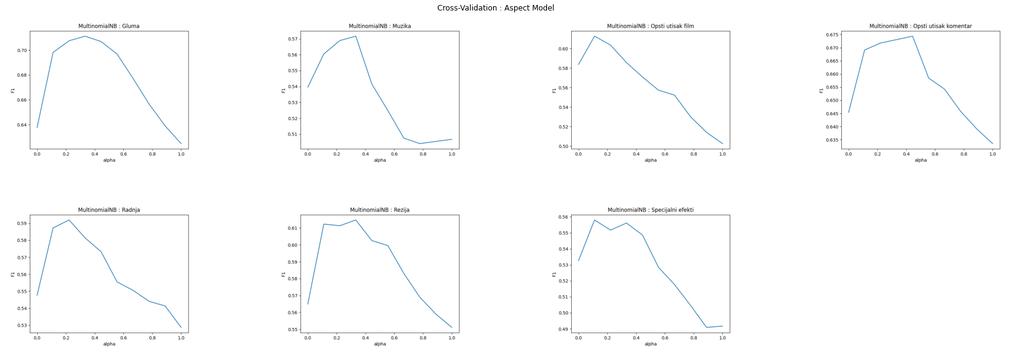

[figure not shown]

Vidimo da se u metodi kros-validacije jasno izdvajaju vrednosti parametra izglađivanja koje maksimizuju prosečni f1 skor nad svim strukovima

Na trenirajućem skupu vrednosti F1 skora su gotovo u svim konfiguracijama preko 90% izuzev konfiguracije u kojoj je korišćeno TF-IDF ponderisanje (razlog za ovo je što u ovom slučaju obeležja odstupaju od kategoričke raspodele što u teoriji čini model Multinomijalnog Naivnog Bayes-a neadekvatnim). Pogledajmo primer matrica konfuzije, opet na poslednjoj konfiguraciji

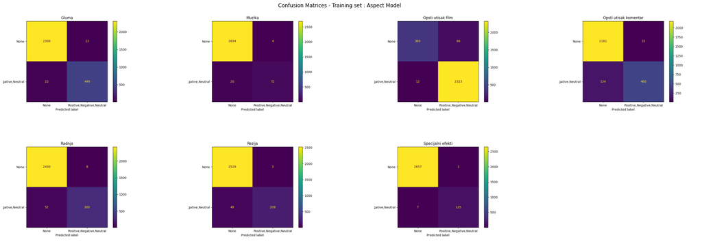

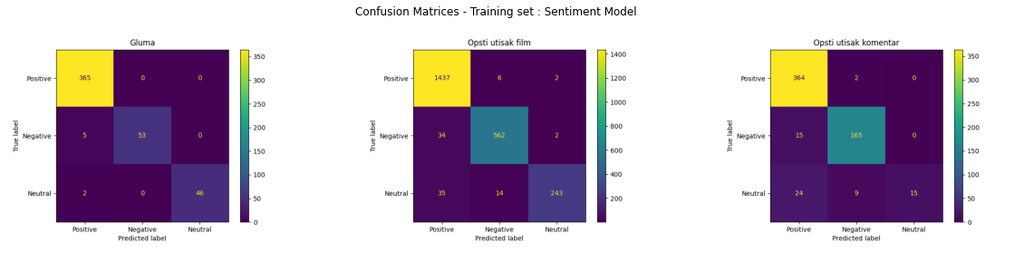

Iako su metrike na trening skupu jako dobre. Mi iz metrika iz kros-validacije (koje su dosta lošije) vidimo da naš model možda i ne generalizuje toliko dobro, naročito ne kod predviđanja sentimenata, odnosno dolazi do preobučavanja. Ovu hipotezu ćemo potvrditi u analizi metrika iz test skupa.

### Testiranje (Evaluacija)

U nastavku su tabelarno prikazani F1 skorovi za model koji je treniran pri različitim konfiguracijama, kao i matrice konfiuzije za već pomenutu poslednju konfiguraciju.

#### Aspekt-Model

|  | initial | lowercase | lowercase, tfidf | lowercase, binary BOW | lowercase, 2-gram | lowercase, stop-words | lowercase, stop-words, stem |
| --- | --- | --- | --- | --- | --- | --- | --- |
| Opsti utisak film | 0.620652 | 0.612452 | 0.450890 | 0.594706 | 0.529704 | 0.587480 | 0.574274 |
| Radnja | 0.582946 | 0.591330 | 0.354344 | 0.591219 | 0.580184 | 0.578898 | 0.602638 |
| Rezija | 0.601605 | 0.610285 | 0.261682 | 0.600605 | 0.547281 | 0.604505 | 0.575089 |
| Gluma | 0.671540 | 0.681098 | 0.292063 | 0.680746 | 0.545331 | 0.661799 | 0.671096 |
| Muzika | 0.537939 | 0.529138 | 0.318182 | 0.540318 | 0.491455 | 0.497374 | 0.528581 |
| Opsti utisak komentar | 0.663144 | 0.676970 | 0.439947 | 0.653490 | 0.612329 | 0.650355 | 0.674426 |
| Specijalni efekti | 0.554271 | 0.550161 | 0.306011 | 0.568669 | 0.477490 | 0.572435 | 0.583182 |
| Average | 0.604585 | 0.607348 | 0.346160 | 0.604250 | 0.540539 | 0.593264 | 0.601327 |

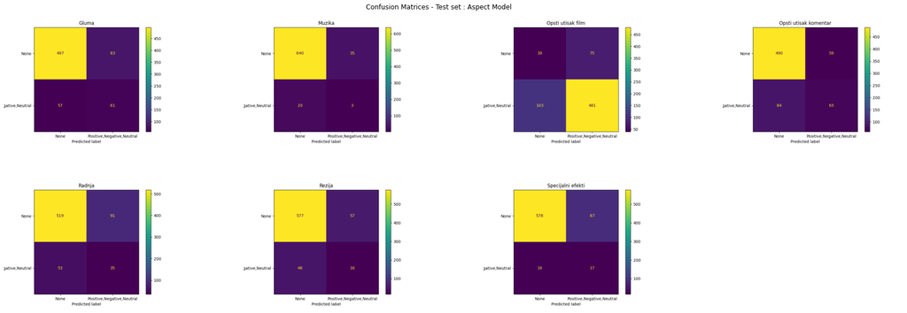

#### Sentiment-Model

|  | initial | lowercase | lowercase, tfidf | lowercase, binary BOW | lowercase, 2-gram | lowercase, stop-words | lowercase, stop-words, stem |
| --- | --- | --- | --- | --- | --- | --- | --- |
| Gluma | 0.365333 | 0.412102 | 0.292063 | 0.412102 | 0.371872 | 0.363521 | 0.469961 |
| Opsti utisak film | 0.579772 | 0.579279 | 0.450890 | 0.576231 | 0.504197 | 0.545875 | 0.560161 |
| Opsti utisak komentar | 0.483673 | 0.469744 | 0.439947 | 0.455751 | 0.434010 | 0.449313 | 0.506287 |
| Average | 0.476259 | 0.487042 | 0.394300 | 0.481361 | 0.436693 | 0.452903 | 0.512136 |

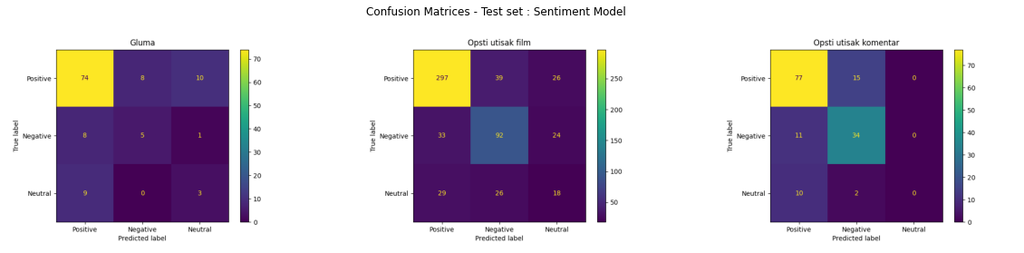

Na osnovu ovih podataka, potvrđujemo inicijalnu pretpostavku da je došlo do preobučavanja. Kod predviđanja aspektnih kategorija ne vidimo da se izdvaja konfiguracija sa najboljim metrikama. Jedino prepoznajemo da korišćenje TF-IDF ponderisanja nije adekvatno za ovakav model. Takođe vidimo da model treniran sa bigram reprezentacijama daje skoro najlošije performanse na test skupu iako je na trening skupu za neke klase davao stoprocentnu tačnost.

Kod predviđanja sentimenta vidimo da se izdvaja model treniran sa poslednjom konfiguracijom kao najbolji iako su njegove performanse daleko lošije od prihvatljivih.

#### Frekvencijsko filtriranje reči

Kao jedna od metoda kojom se potencijalno mogu poboljšati modeli jeste korišćenje samo onih reči iz vokabulara koje se najčešće pojavljuju kao BOW obeležja. Pokrenuli smo trening sa poslednjom konfiguracijom uz zadržavanje 1000 najučestalijih reči. U nastavku je prikazana svaka 15-ta reč iz ovakvog vokabulara.

```
['10', '910', 'atmosfer', 'bit', 'broj', 'cin', 'cxi', 'dalj',
   'desxav', 'dodx', 'dredd', 'efek', 'fantasticx', 'general',
   'glumi', 'gub', 'iko', 'ispad', 'izbor', 'jedi', 'karakter', 'kod',
   'krajnj', 'kvar', 'los', 'mas', 'mnog', 'mozak', 'najv', 'nasl',
   'negativ', 'nika', 'nos', 'ocigled', 'odigr', 'omilje', 'original',
   'otprili', 'pam', 'plus', 'pojavlj', 'por', 'posxt', 'predstav',
   'prevod', 'pro', 'prostor', 'razl', 'recx', 'rodite', 'sce',
   'simpaticx', 'slicx', 'sni', 'srbij', 'strasx', 'svidj', 'tekst',
   'tob', 'trenu', 'uglavn', 'uradxen', 'valj', 'vid', 'you', 'zar',
   'znacx']
```

Pri čemu je bitno da stemmer pretvara "č" u "cx", "š" u "sx" itd..

U nastavku je prikazano poređenje performansi na test skupu na poslednoj konfiguraciji kad se koristi i kad se ne koristi frekvencijsko filtriranje reči

Aspekt-Model

|  | initial | lowercase | lowercase, tfidf | lowercase, binary BOW | lowercase, 2-gram | lowercase, stop-words | lowercase, stop-words, stem | lowercase, stop-words, stem, max 1000 features |
| --- | --- | --- | --- | --- | --- | --- | --- | --- |
| Opsti utisak film | 0.620652 | 0.612452 | 0.450890 | 0.594706 | 0.529704 | 0.587480 | 0.574274 | 0.572821 |
| Radnja | 0.582946 | 0.591330 | 0.354344 | 0.591219 | 0.580184 | 0.578898 | 0.602638 | 0.629308 |
| Rezija | 0.601605 | 0.610285 | 0.261682 | 0.600605 | 0.547281 | 0.604505 | 0.575089 | 0.569136 |
| Gluma | 0.671540 | 0.681098 | 0.292063 | 0.680746 | 0.545331 | 0.661799 | 0.671096 | 0.745066 |
| Muzika | 0.537939 | 0.529138 | 0.318182 | 0.540318 | 0.491455 | 0.497374 | 0.528581 | 0.686356 |
| Opsti utisak komentar | 0.663144 | 0.676970 | 0.439947 | 0.653490 | 0.612329 | 0.650355 | 0.674426 | 0.701268 |
| Specijalni efekti | 0.554271 | 0.550161 | 0.306011 | 0.568669 | 0.477490 | 0.572435 | 0.583182 | 0.647370 |

Sentiment-Model

|  | initial | lowercase | lowercase, tfidf | lowercase, binary BOW | lowercase, 2-gram | lowercase, stop-words | lowercase, stop-words, stem | lowercase, stop-words, stem, max 1000 features |
| --- | --- | --- | --- | --- | --- | --- | --- | --- |
| Gluma | 0.365333 | 0.412102 | 0.292063 | 0.412102 | 0.371872 | 0.363521 | 0.469961 | 0.547173 |
| Opsti utisak film | 0.579772 | 0.579279 | 0.450890 | 0.576231 | 0.504197 | 0.545875 | 0.560161 | 0.392477 |
| Opsti utisak komentar | 0.483673 | 0.469744 | 0.439947 | 0.455751 | 0.434010 | 0.449313 | 0.506287 | 0.472938 |

Vidimo da je f1 skor kod predviđanja aspektne kategorije poboljšan, i dalje dolazi do preobučavanja ali su metrike bolje nego na prethodnim konfiguracijama. Ovo ima smisla jer je intuitivno moguće dodeliti aspektnu kategoriju samo na osnovu par reči iz komentara. (Npr. kada se reč "gluma" ili "muzika" se pojavljuju u komentarima koji pripadaju istoimenim kategorijama)

## Metoda potpornih vektora (RBF kernel)

Kod ove vrste diskriminativnih modela, vreme izvršavanja kros-validacije je bilo veliko. Zbog toga smo radili frekvencijsko filtriranje reči na svim konfiguracijama tako što smo zadržali 5000 najučestalijih reči. Korišćen je Radial basis function kernel koji čini ovaj model nelinearnim klasifikatorom.

Kao i za prethodni model urađeno je poređenje između različitih konfiguracija koje su se autorima činile najintuitivnijim.

Kao hiperparametar koristili smo regularizacionu konstantu $C$. Za svaku konfiguraciju pokrenuta je krosvalidacija kako bi se našao optimalan parametar. Pri čemu je korišćeno deset vrednosti ovog parametra u opsegu od 0 do 1.

U nastavku su tabelarno prikazani rezultati za različite konfiguracije

#### Predviđanje aspektnih kategorija

##### Optimalni hiperparametri

|  | lowercase, max 5000 features | lowercase, tfidf, max 5000 features | lowercase, tfidf, stop-words, stem, max 5000 features |
| --- | --- | --- | --- |
| Opsti utisak film | 1.0000 | 0.3334 | 0.3334 |
| Radnja | 0.8889 | 0.4445 | 0.2223 |
| Rezija | 0.5556 | 0.2223 | 0.2223 |
| Gluma | 0.8889 | 0.6667 | 0.6667 |
| Muzika | 0.2223 | 0.1112 | 0.2223 |
| Opsti utisak komentar | 1.0000 | 0.7778 | 0.7778 |
| Specijalni efekti | 0.5556 | 0.1112 | 0.1112 |

##### F1 metrika tokom kros-validacije (usrednjena na svim strukovima)

|  | lowercase, max 5000 features | lowercase, tfidf, max 5000 features | lowercase, tfidf, stop-words, stem, max 5000 features |
| --- | --- | --- | --- |
| Opsti utisak film | 0.649948 | 0.698875 | 0.696168 |
| Radnja | 0.694601 | 0.695921 | 0.720228 |
| Rezija | 0.610358 | 0.616912 | 0.631634 |
| Gluma | 0.670431 | 0.710120 | 0.774913 |
| Muzika | 0.613516 | 0.583441 | 0.613609 |
| Opsti utisak komentar | 0.738948 | 0.764912 | 0.738570 |
| Specijalni efekti | 0.636472 | 0.636123 | 0.624038 |

##### F1 metrika na trening skupu

|  | lowercase, max 5000 features | lowercase, tfidf, max 5000 features | lowercase, tfidf, stop-words, stem, max 5000 features |
| --- | --- | --- | --- |
| Opsti utisak film | 0.623994 | 0.462427 | 0.455610 |
| Radnja | 0.731528 | 0.475054 | 0.466335 |
| Rezija | 0.475761 | 0.475761 | 0.475761 |
| Gluma | 0.730999 | 0.703887 | 0.839161 |
| Muzika | 0.491618 | 0.491618 | 0.491618 |
| Opsti utisak komentar | 0.839521 | 0.890494 | 0.869934 |
| Specijalni efekti | 0.487885 | 0.487885 | 0.487885 |

#### Predviđanje sentimenata

##### Optimalni hiperparametri

|  | lowercase, max 5000 features | lowercase, tfidf, max 5000 features | lowercase, tfidf, stop-words, stem, max 5000 features |
| --- | --- | --- | --- |
| Gluma | 0.3334 | 0.4445 | 0.4445 |
| Opsti utisak film | 1.0000 | 0.7778 | 0.5556 |
| Opsti utisak komentar | 0.8889 | 0.8889 | 0.8889 |

##### F1 metrika tokom kros-validacije (usrednjena na svim strukovima)

|  | lowercase, max 5000 features | lowercase, tfidf, max 5000 features | lowercase, tfidf, stop-words, stem, max 5000 features |
| --- | --- | --- | --- |
| Gluma | 0.357409 | 0.322462 | 0.312636 |
| Opsti utisak film | 0.555053 | 0.602765 | 0.587539 |
| Opsti utisak komentar | 0.463306 | 0.484357 | 0.462805 |

##### F1 metrika na trening skupu

|  | lowercase, max 5000 features | lowercase, tfidf, max 5000 features | lowercase, tfidf, stop-words, stem, max 5000 features |
| --- | --- | --- | --- |
| Gluma | 0.291069 | 0.291069 | 0.291069 |
| Opsti utisak film | 0.748635 | 0.823135 | 0.532190 |
| Opsti utisak komentar | 0.523477 | 0.691739 | 0.675275 |

Pogledajmo prvo kako izgledaju validacione krive za jednu od konfiguracija (autori su odlucili da to bude konfiguracija - **lowercase, tfidf, max 5000 features**)

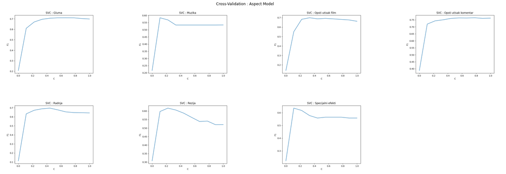

[figure not shown]

Vidimo da se u metodi kros-validacije za pojedine klase izdvajaju vrednosti regularizacionog parametra koji maksimizuju prosečni f1 skor nad svim strukovima. Za neke klase sa povećavanjem vrednosti hiperparametra ne dolazi do značajnih promena u performansama te autori smatraju da je optimalnost hiperparametra u tim slučajevima diskutabilna.

Na trenirajućem skupu vidimo da vrednosti F1 skora nisu velike kao kod Naivnog Bayesa, već su njihove vrednosti uporedivije sa vrednostima dobijenim u kros-validaciji. Ovo ne znači da su metrike dobre, naprotiv one i u ovom slučaju ne ispunjavaju željene kriterijume naročito u slučaju predviđanja sentimenta.

Autori primećuju blagi boljitak performansi kada se koristi tf-idf ponderisanje ali te boljitke ne smatraju značajnim iako je intuitivnije da se float brojevi koriste kao obeležja za ovakve algoritme obučavanja.

Opet, pogledajmo matrice konfuzije (opet na istoj konfiguraciji)

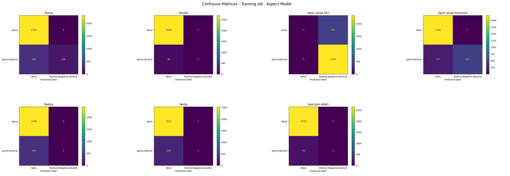

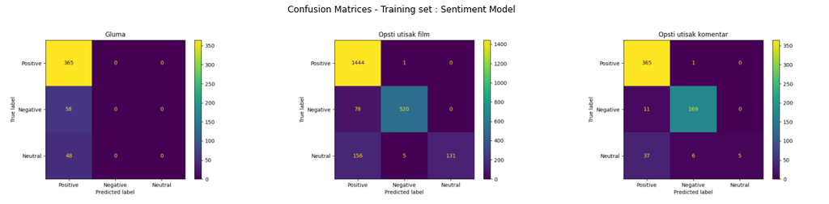

### Testiranje (Evaluacija)

U nastavku su tabelarno prikazani F1 skorovi za model koji je treniran pri različitim konfiguracijama, kao i matrice konfiuzije za već pomenutu konfiguraciju.

#### Aspekt-Model

|  | lowercase, max 5000 features | lowercase, tfidf, max 5000 features | lowercase, tfidf, stop-words, stem, max 5000 features |
| --- | --- | --- | --- |
| Opsti utisak film | 0.455538 | 0.455538 | 0.455538 |
| Radnja | 0.477954 | 0.466361 | 0.466361 |
| Rezija | 0.475976 | 0.475976 | 0.475976 |
| Gluma | 0.541961 | 0.519257 | 0.620585 |
| Muzika | 0.491624 | 0.491624 | 0.491624 |
| Opsti utisak komentar | 0.642435 | 0.615427 | 0.641708 |
| Specijalni efekti | 0.487894 | 0.487894 | 0.487894 |
| Average | 0.510483 | 0.501725 | 0.519955 |

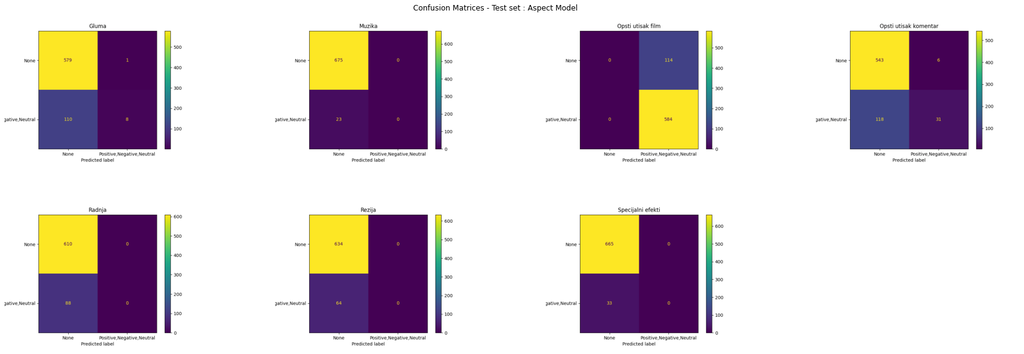

#### Sentiment-Model

|  | lowercase, max 5000 features | lowercase, tfidf, max 5000 features | lowercase, tfidf, stop-words, stem, max 5000 features |
| --- | --- | --- | --- |
| Gluma | 0.292063 | 0.292063 | 0.292063 |
| Opsti utisak film | 0.376195 | 0.450890 | 0.329916 |
| Opsti utisak komentar | 0.440723 | 0.439947 | 0.329400 |
| Average | 0.369661 | 0.394300 | 0.317126 |

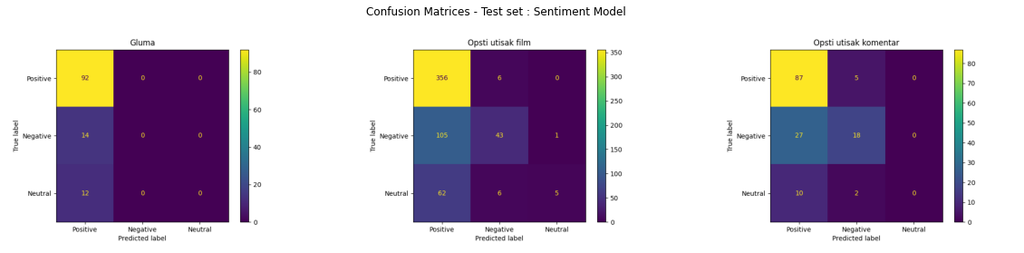

Autori projekta su jako nezadovoljni rezultatima i činjenicom da je vreme izvršavanja kros-validacije i treninga za ovaj model kad se koriste sva obeležja jako veliko. Ipak ono što se pokazalo kao ne toliko vremenski zahtevno jeste obučavanje metode potpornih vektora kad se koristi linearan kernel zajedno sa svim obeležjima. Zato je odrađen još jedan eksperiment gde se koristi metoda potpornih vektora sa linearnim kernelom. Korišćena konfiguracija u ovom eksperimentu je `lowercase, tfidf, stop-words, stem`.

U nastavku je prikazana tabela sa f1 skorovima za aspekt i sentiment model na test skupu.

## Metoda potpornih vektora (Linearan kernel)

|  | lowercase, tfidf, stop-words, stem |
| --- | --- |
| Opsti utisak film | 0.623468 |
| Radnja | 0.714525 |
| Rezija | 0.626867 |
| Gluma | 0.823443 |
| Muzika | 0.844033 |
| Opsti utisak komentar | 0.722560 |
| Specijalni efekti | 0.774456 |

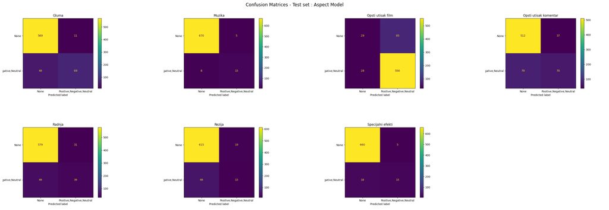

|  | lowercase, tfidf, stop-words, stem |
| --- | --- |
| Gluma | 0.433002 |
| Opsti utisak film | 0.551494 |
| Opsti utisak komentar | 0.466500 |

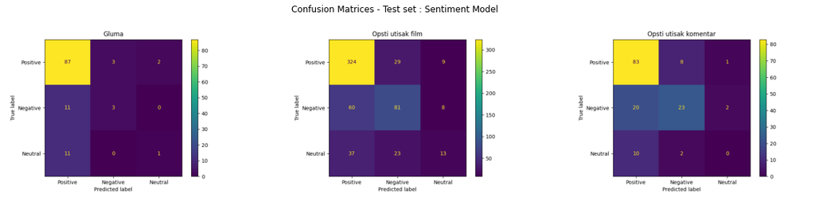

Ovde vidimo da model sa linearnim kernelom dosta bolje performanse ima nego sa RBF kernelom, naročito kod predviđanja aspektne kategorije. Kod predviđanja sentimenta opet imamo bolji rezultat ali je on daleko od zadovoljavajućeg.

## Logistička regresija

Kao što je već pomenuto ovo je diskriminativni model i on predstavlja linearni klasifikator. Takođe je pomenuto da je reprezentativna moć ovog modela je manja ili jednaka reprezentativnoj moći metode potpornih vektora te nismo razmatrali previše konfiguracija.

Opet kao i za sve modele rađena je kros-validacija gde je tražen optimalni regularizacioni parametar $\lambda$ (korišćena je L2 regularizacija).

U nastavku su tabelarno prikazani rezultati za različite konfiguracije

#### Predviđanje aspektnih kategorija

##### Optimalni hiperparametri

|  | lowercase, tfidf, stop-words, stem |
| --- | --- |
| Opsti utisak film | 0.8889 |
| Radnja | 0.8889 |
| Rezija | 0.5556 |
| Gluma | 0.7778 |
| Muzika | 0.3334 |
| Opsti utisak komentar | 0.2223 |
| Specijalni efekti | 0.2223 |

##### F1 metrika tokom kros-validacije (usrednjena na svim strukovima)

|  | lowercase, tfidf, stop-words, stem |
| --- | --- |
| Opsti utisak film | 0.703493 |
| Radnja | 0.720455 |
| Rezija | 0.661830 |
| Gluma | 0.799827 |
| Muzika | 0.804413 |
| Opsti utisak komentar | 0.767773 |
| Specijalni efekti | 0.772039 |

##### F1 metrika na trening skupu

|  | lowercase, tfidf, stop-words, stem |
| --- | --- |
| Opsti utisak film | 0.526185 |
| Radnja | 0.494853 |
| Rezija | 0.475761 |
| Gluma | 0.630697 |
| Muzika | 0.491618 |
| Opsti utisak komentar | 0.497003 |
| Specijalni efekti | 0.487885 |

#### Predviđanje sentimenata

##### Optimalni hiperparametri

|  | lowercase, tfidf, stop-words, stem |
| --- | --- |
| Gluma | 0.0001 |
| Opsti utisak film | 0.5556 |
| Opsti utisak komentar | 0.0001 |

##### F1 metrika tokom kros-validacije (usrednjena na svim strukovima)

|  | lowercase, tfidf, stop-words, stem |
| --- | --- |
| Gluma | 0.377241 |
| Opsti utisak film | 0.629663 |
| Opsti utisak komentar | 0.510953 |

##### F1 metrika na trening skupu

|  | lowercase, tfidf, stop-words, stem |
| --- | --- |
| Gluma | 0.291069 |
| Opsti utisak film | 0.592300 |
| Opsti utisak komentar | 0.254167 |

### Testiranje (Evaluacija)

#### Aspekt-Model

U nastavku su tabelarno prikazani F1 skorovi i matrice konfuzije

|  | lowercase, tfidf, stop-words, stem |
| --- | --- |
| Opsti utisak film | 0.472919 |
| Radnja | 0.499633 |
| Rezija | 0.475976 |
| Gluma | 0.534504 |
| Muzika | 0.491624 |
| Opsti utisak komentar | 0.461055 |
| Specijalni efekti | 0.487894 |

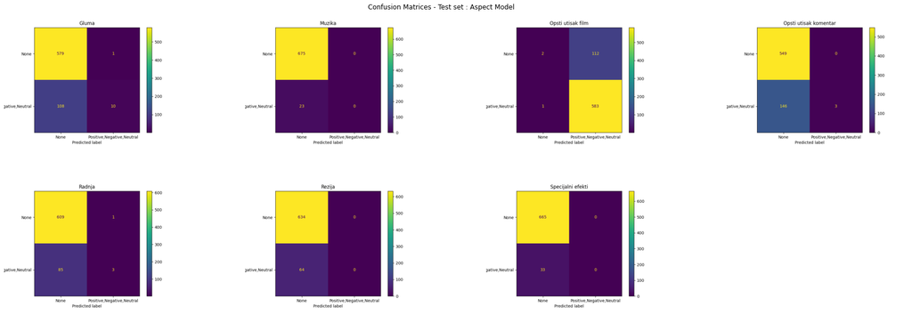

|  | lowercase, tfidf, stop-words, stem |
| --- | --- |
| Gluma | 0.292063 |
| Opsti utisak film | 0.430006 |
| Opsti utisak komentar | 0.254495 |

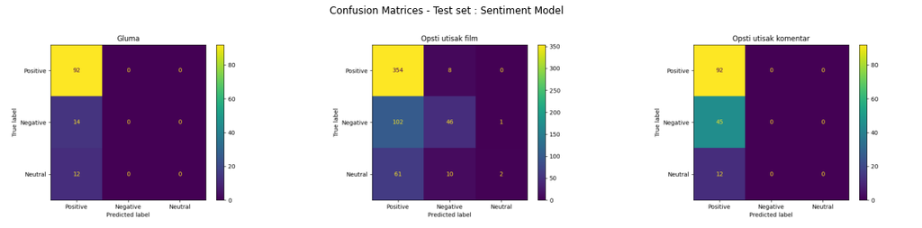

Iz datih rezultata zaključujemo da model Logističke regresije za ovakav skup podataka i za BOW način formiranja obeležja daje jako loše rezultate. Lošije nego kod prethodnih modela iako i kod njih nisu bili zadovoljavajući rezultati.